# Schizophrenia Spectrum Disorder Networks

Lindley Slipetz

2/16/2021

The purpose of this project is to assess the positive and negative symptom network of schizophrenia. Originally, I wanted to compare schizophrenia to schizoaffective; but, unfortunately, the schizoaffective sample was too small. I’ve left some comparisons, but I can’t compare networks. We will be using three datasets from [SchizConnect](http://schizconnect.org/). We’ll start by loading packages and data. I want to use the new EGAnet so I get pretty graphs, so I’ll start by installing that.

```r
#detach(package:EGAnet, unload = TRUE)
#install.packages("EGAnet")
```

Now I’m going to load all of these packages.

```r
library(tidyverse)
library(polycor)
library(EGAnet)
```

Here’s the data!

```r
fBIRN <- read.csv("G:\\My Drive\\DataScience\\Schizophrenia_data\\fBIRN.csv", header = TRUE, stringsAsFactors = FALSE)
NMorph <- read.csv("G:\\My Drive\\DataScience\\Schizophrenia_data\\NMorph.csv", header = TRUE, stringsAsFactors = FALSE)
NUSDAST <- read.csv("G:\\My Drive\\DataScience\\Schizophrenia_data\\NUSDAST.csv", header = TRUE, stringsAsFactors = FALSE)
```

This data is super messy: it’s in long form and the variable names don’t match. We have a lot of work to do! Before we put it into wide form, we’ll need to limit the data to a particular time point for NMorph and NUSDAST.

```r
NMorph <- NMorph %>%
  filter(visit == 0)
NUSDAST <- NUSDAST %>%
  filter(visit == 0)
```

Next, we’ll subset the data to just the data we’re interested in so we don’t end up with a million columns when we turn the data wide.

```r
subset_fBIRN <- subset(fBIRN, (assessment_description == "Scale for the Assessment of Negative Symptoms" | assessment_description == "Scale for the Assessment of Positive Symptoms") | question_id %in% c("SCID_P47", "SCID_P48", "SCID_P53", "SCID_P54"))
subset_NMorph <- subset(NMorph, (assessment_description == "Scale for the Assessment of Negative Symptoms" | assessment_description == "Scale for the Assessment of Positive Symptoms") | question_id %in% c("scidp47_c", "scidp53_c"))
subset_NUSDAST <- subset(NUSDAST, (assessment_description == "Scale for the Assessment of Negative Symptoms" | assessment_description == "Scale for the Assessment of Positive Symptoms") | question_id %in% c("scidp47", "scidp53"))
```

We have a bunch of columns that we don’t need. Let’s get rid of those before going wide.

```r
fBIRN_col <- subset(subset_fBIRN, select = -c(source, site, visit, assessment,
                                       assessment_description))
NMorph_col <- subset(subset_NMorph, select = -c(source, site, visit, assessment,
                                       assessment_description))
NUSDAST_col <- subset(subset_NUSDAST, select = -c(source, site, visit, assessment,
                                       assessment_description))
```

Now we can make the datasets wide!

```r
fBIRN.wide <- reshape(fBIRN_col, timevar = "question_id",
             idvar = c("subjectid", "study"), direction = "wide")
NMorph.wide <- reshape(NMorph_col, timevar = "question_id",
             idvar = c("subjectid", "study"), direction = "wide")
NUSDAST.wide <- reshape(NUSDAST_col, timevar = "question_id",
             idvar = c("subjectid", "study"), direction = "wide")
```

Let’s rename the columns we want to work with before cutting columns again. For fBIRN, we’re looking for the Scale for the Assessment of Negative Symptoms (SANS) and Scale for the Assessment of Positive Symptoms (SAPS) data. When I first did this project, Veronica matched the variable name to the name in the actual measure, but I’ve coded it. fBIRN is the only anomaly, so we’ll just be renaming those SANS/SAPS columns to match the NMorph and NUSDAST datasets. The NMorph and NUSDAST just have weird columns names after the “widening”, so we’ll be deleting the “question_value.” suffix from those datasets.

```r
names(fBIRN.wide) <- gsub(pattern = "question_value.", replacement = "", x = names(fBIRN.wide))
fBIRN_rename <- fBIRN.wide %>%
  rename(sans1 = 'Unchanging Facial Expression',
         sans2 = SS12,
         sans3 = SS13,
         sans4 = SS14,
         sans5 = SS15,
         sans7 = SS16,
         sans8 = SS17,
         sans6 = SS18,
         sans9 = SS19,
         sans10 = SS20,
         sans11 = SS21,
         sans12 = SS22,
         sans13 = SS23,
         sans14 = SS24,
         sans15 = SS25,
         sans16 = SS26,
         sans17 = SS27,
         sans18 = SS28,
         sans19 = SS29,
         sans20 = SS30,
         sans21 = SS31,
         sans22 = SS32,
         sans23 = SS33,
         sans24 = SS34,
         sans25 = SS35,
         saps1 = SS36,
         saps2 = SS37,
         saps3 = SS38,
         saps4 = SS39,
         saps5 = SS40,
         saps6 = SS41,
         saps7 = SS42,
         saps8 = SS43,
         saps9 = SS44,
         saps10 = SS45,
         saps11 = SS46,
         saps12 = SS47,
         saps13 = SS48,
         saps14 = SS49,
         saps15 = SS50,
         saps16 = SS51,
         saps17 = SS52,
         saps18 = SS53,
         saps19 = SS54,
         saps20 = SS55,
         saps21 = SS56,
         saps22 = SS57,
         saps23 = SS58,
         saps24 = SS59,
         saps25 = SS60,
         saps26 = SS61,
         saps27 = SS62,
         saps28 = SS63,
         saps29 = SS64,
         saps30 = SS65,
         saps31 = SS66,
         saps32 = SS67,
         saps33 = SS68,
         saps34 = SS69)
names(NMorph.wide) <- gsub(pattern = "question_value.", replacement = "", x = names(NMorph.wide))
names(NUSDAST.wide) <- gsub(pattern = "question_value.", replacement = "", x = names(NUSDAST.wide))
```

Now we’re going to make a new column for each data frame, ‘SSD’. This will tell if someone has a diagnosis of schizophrenia, schizoaffective or other.

```r
fBIRN_complete <- fBIRN_rename %>%
  mutate(
    SSD = case_when(
      SCID_P48 == 3 | SCID_P47 == 3 ~ "Schizophrenia",
      SCID_P54 == 3 | SCID_P53 == 3 ~ "Schizoaffective",
      TRUE                          ~ "Other"
    )
  )
NMorph_complete <- NMorph.wide %>%
  mutate(
    SSD = case_when(
      scidp47_c == 3 ~ "Schizophrenia",
      scidp53_c == 3 ~ "Schizoaffective",
      TRUE                          ~ "Other"
    )
  )
NUSDAST_complete <- NUSDAST.wide %>%
  mutate(
    SSD = case_when(
      scidp47 == 3 ~ "Schizophrenia",
      scidp53 == 3 ~ "Schizoaffective",
      TRUE                          ~ "Other"
    )
  )
```

Okay, now we have all the information we need. Now we just need to delete the subjectid, study, and non-SSD diagnosis columns. Then we can join all the datasets together. The column with a space in fBIRN (“Proband Interview”) was giving me problems so I deleted that separately.

```r
fBIRN_complete$"Proband Interview" <- NULL
fBIRN_complete <- subset(fBIRN_complete, select = -c(subjectid, study, SCID_P53, SCID_P47, SCID_P48, SCID_P54, Family, Friends, Medication, Other, Staff, Status, SS3, SS4, Reliability))
NMorph_complete <- subset(NMorph_complete, select = -c(study, subjectid, scidp47_c, scidp53_c))
NUSDAST_complete <- subset(NUSDAST_complete, select = -c(study, subjectid, scidp47, scidp53))
```

Okay, now what we’ve been waiting for: we’re going to make one giant dataset (okay, maybe that’s not what we’ve been waiting for, but it’s an exciting step).

```r
data_complete <- rbind(fBIRN_complete, NMorph_complete, NUSDAST_complete)
```

So you probably think our data is ready now, but there’s just one last thing we need to do. The SANS and SAPS use summary scores in the measure. We just want the item level data, not the global scores. Let’s delete the global scores.

```r
data_complete <- subset(data_complete, select = -c(sans8, sans13, sans17, sans22, sans25, saps7, saps20, saps25, saps34))
```

Our final step before analysis is to limit the data to only Schizophrenia and Schizoaffective diagnoses.

```r
SSD_data <- data_complete %>%
  filter(SSD == "Schizophrenia" | SSD == "Schizoaffective")
```

Finally! We have our data tidy. Now we can start analyzing it. When I used this data for my first year project, I used only the SANS data. I found that there were two factors for both schizophrenia and schizoaffective: psychomotor poverty and anhedonia. Now we’re going to do EGA to see the factors of both SANS and SAPS. We’ll start with polychoric correlations because the data is ordinal.

```r
SSD_data[,1:50] <- lapply(SSD_data[,1:50], as.numeric)
all_corr <- polycor::hetcor(SSD_data[,1:50])
```

Yay! Now we have correlations. Let’s look in more detail at the highest and lowest correlations. We’ll start by arranging the correlations in descending order using a code found here: [Arranging correlations](https://stackoverflow.com/questions/46308308/find-the-pair-of-most-correlated-variables)

```r
all_corr$correlations %>%
  as.data.frame() %>%
  mutate(var1 = rownames(.)) %>%
  gather(var2, value, -var1) %>%
  arrange(desc(value))
```

```
##        var1   var2         value
## 1     sans2  sans2  1.000000e+00
## 2     sans3  sans3  1.000000e+00
## 3     sans4  sans4  1.000000e+00
## 4     sans5  sans5  1.000000e+00
## 5     sans7  sans7  1.000000e+00
## 6     sans6  sans6  1.000000e+00
## 7     sans9  sans9  1.000000e+00
## 8    sans10 sans10  1.000000e+00
## 9    sans11 sans11  1.000000e+00
## 10   sans12 sans12  1.000000e+00
## 11   sans14 sans14  1.000000e+00
## 12   sans15 sans15  1.000000e+00
## 13   sans16 sans16  1.000000e+00
## 14   sans18 sans18  1.000000e+00
```

[output cut: 2486 more lines]

sans 7 (lack of vocal inflections) and sans 3 (paucity of expressive gestures) have the highest correlation (.87) and sans21 (relationships with friends and peers) and saps15 (delusions of being controlled) have the lowest correlation (.23). Let’s look at graphs to explore these correlation by diagnosis. We’ll start with the high correlation between sans 7 and sans 3.

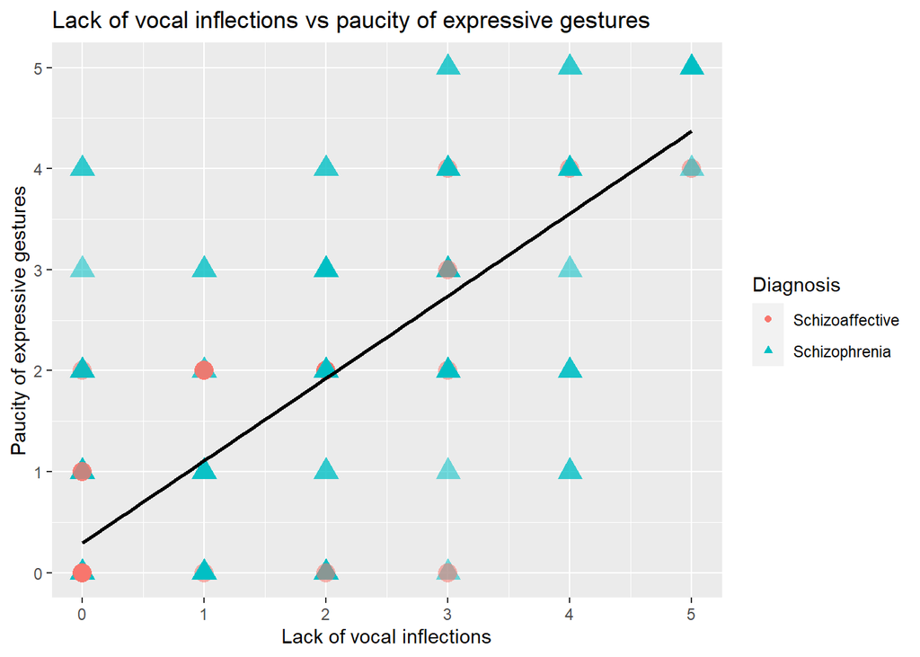

```r
SSD_data %>%
  ggplot(aes(x=sans7, y=sans3)) +
  geom_point(aes(shape = SSD, color = SSD, alpha = .1, size = 3)) +
  geom_smooth(method=lm, se=FALSE, fullrange=TRUE, colour = 'black') +
  labs(title="Lack of vocal inflections vs paucity of expressive gestures",
       x="Lack of vocal inflections", y = "Paucity of expressive gestures", shape = "Diagnosis", color = "Diagnosis") +
  guides(alpha = FALSE, size = FALSE)
```

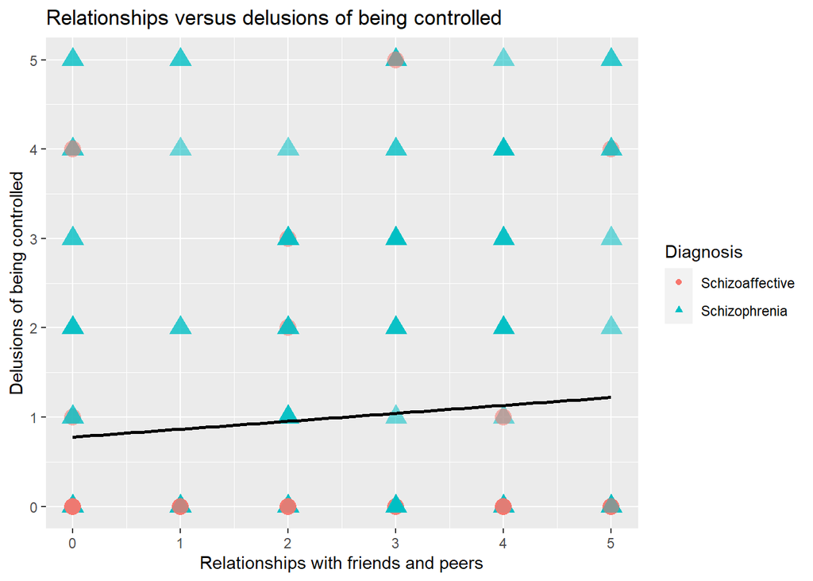

```r
SSD_data %>%
  ggplot(aes(x=sans21, y=saps15)) +
  geom_point(aes(shape = SSD, color = SSD, alpha = .1, size = 3)) +
  geom_smooth(method=lm, se=FALSE, fullrange=TRUE, colour = 'black') +
  labs(title="Relationships versus delusions of being controlled",
       x="Relationships with friends and peers", y = "Delusions of being controlled", shape = "Diagnosis", color = "Diagnosis") +
  guides(alpha = FALSE, size = FALSE)
```

Now we’re ready for the schizophrenia network! I ran the code once to see what the structure is. I’ll also add the legend at this step based on the previous run. The factors are based on Peralta, V. & Cuesta, M.J (1999). “Dimensional structure of psychotic symptoms: an item-level analysis of SAPS and SANS symptoms in psychotic disorders.” Schizophrenia Research, 38, 13-26.

*Note: I can’t figure out how to change the legend font size, so I had to use annoying abbreviations. The real factors are Schneiderian delusions/auditory hallucinations, social dysfunction, religious/paranoid delusions and nonauditory hallucinations, bizarre behavior, thought disorder, poverty of affect/speech, and attention.

```r
SZ_data <- SSD_data %>%
  filter(SSD == "Schizophrenia")
SZ_EGA <- EGA(SZ_data[,1:50], uni = TRUE, model = c("glasso"), algorithm =
                c("walktrap"), plot.EGA = FALSE, verbose = TRUE)
```

```
## Variables detected as ordinal: sans2; sans3; sans4; sans7; sans6; sans9; sans10; sans11; sans12; sans14; sans15; sans16; sans18; sans19; sans20; sans21; sans23; sans24; sans1; saps1; saps2; saps3; saps4; saps5; saps6; saps8; saps9; saps10; saps11; saps12; saps13; saps14; saps15; saps16; saps17; s…
```

```
## Network estimated with:
##  • gamma = 0.5
##  • lambda.min.ratio = 0.1
```

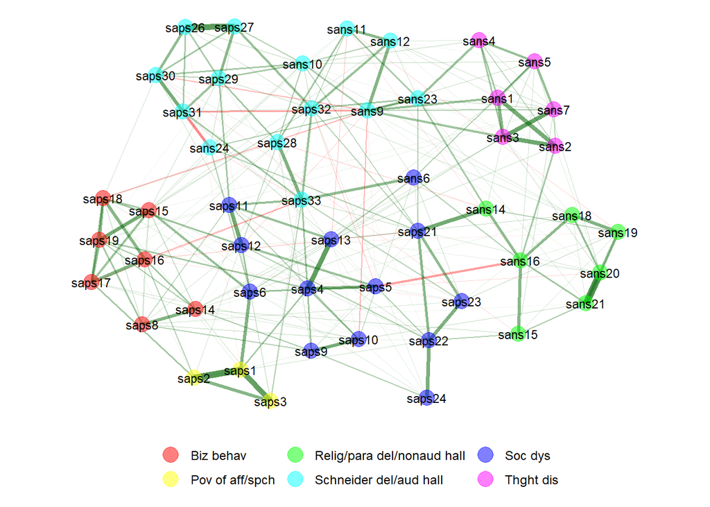

```r
SZ_plot <- plot(SZ_EGA, plot.args = list(vsize = 5, alpha = 0.5, edge.alpha = 0.5,  legend.names = c("Schneider del/aud hall", "Soc dys", "Relig/para del/nonaud hall", "Biz behav", "Thght dis", "Pov of aff/spch", "Attn"),  color.palette = "rainbow", label.size = 3, legend.position="bottom"))
```

Let’s take a look at the fit of this network.

```r
SZ_fit <- CFA(SZ_EGA , SZ_data[,1:50], "WLSMV", plot.CFA = FALSE)
```

```
##  [1] sans9  sans10 sans11 sans12 sans23 sans24 saps26 saps27 saps28 saps29
## [11] saps30 saps31 saps32 saps33
## 50 Levels: sans1 sans10 sans11 sans12 sans14 sans15 sans16 sans18 ... saps9
##  [1] sans6  saps4  saps5  saps6  saps9  saps10 saps11 saps12 saps13 saps21
## [11] saps22 saps23 saps24
## 50 Levels: sans1 sans10 sans11 sans12 sans14 sans15 sans16 sans18 ... saps9
## [1] sans14 sans15 sans16 sans18 sans19 sans20 sans21
## 50 Levels: sans1 sans10 sans11 sans12 sans14 sans15 sans16 sans18 ... saps9
## [1] saps8  saps14 saps15 saps16 saps17 saps18 saps19
## 50 Levels: sans1 sans10 sans11 sans12 sans14 sans15 sans16 sans18 ... saps9
## [1] sans2 sans3 sans4 sans5 sans7 sans1
## 50 Levels: sans1 sans10 sans11 sans12 sans14 sans15 sans16 sans18 ... saps9
## [1] saps1 saps2 saps3
## 50 Levels: sans1 sans10 sans11 sans12 sans14 sans15 sans16 sans18 ... saps9
```

```r
SZ_fit$fit.measures
```

```
## chisq.scaled           df       pvalue   cfi.scaled rmsea.scaled
##     1389.053     1160.000        0.000        0.750        0.034
```

The RMSEA of the model is 0.034, which indicates good fit; however, CFI is 0.75 which does not indicate a good fit. If I were pursuing this as a real project, I would probably make some adjustments to the model at this point (e.g., maybe dropping variables).

In conclusion, I’ve presented a 6 cluster solution for schizophrenia using EGA. I would have liked to present a schizoaffective network, but the sample size was too small. For future directions, I would maybe eliminate some variables to improve fit and look at centrality measures.